# Risk Factor Analysis

## Outcome Variable

**Outcome Variable:** y_rate_len

## Predictor Variables

**Intervention Variable:** nchldlt5

**Adjustment Set:**

- arm
- W_mage
- meducyrs
- feducyrs
- hhwealth_quart
- hfoodsec
- W_mhtcm
- W_nrooms
- W_parity
- impfloor
- impsan
- safeh20
- delta_W_mage
- delta_meducyrs
- delta_feducyrs
- delta_hhwealth_quart
- delta_hfoodsec
- delta_W_mhtcm
- delta_W_nrooms
- delta_W_parity
- delta_impfloor
- delta_impsan
- delta_safeh20

## Stratifying Variables

The analysis was stratified on these variable(s):

- agecat
- studyid
- country

## Data Summary

| agecat | studyid | country | nchldlt5 | n_cell | n |
| --- | --- | --- | --- | --- | --- |
| 0-3 months | ki1017093b-PROVIDE | BANGLADESH | 1 | 467 | 634 |
| 0-3 months | ki1017093b-PROVIDE | BANGLADESH | 2 | 158 | 634 |
| 0-3 months | ki1017093b-PROVIDE | BANGLADESH | 3+ | 9 | 634 |
| 0-3 months | ki1017093c-NIH-Crypto | BANGLADESH | 1 | 511 | 720 |
| 0-3 months | ki1017093c-NIH-Crypto | BANGLADESH | 2 | 203 | 720 |
| 0-3 months | ki1017093c-NIH-Crypto | BANGLADESH | 3+ | 6 | 720 |
| 0-3 months | kiGH5241-JiVitA-3 | BANGLADESH | 1 | 12472 | 20027 |
| 0-3 months | kiGH5241-JiVitA-3 | BANGLADESH | 2 | 7095 | 20027 |
| 0-3 months | kiGH5241-JiVitA-3 | BANGLADESH | 3+ | 460 | 20027 |
| 0-3 months | ki1000108-IRC | INDIA | 1 | 82 | 377 |
| 0-3 months | ki1000108-IRC | INDIA | 2 | 109 | 377 |
| 0-3 months | ki1000108-IRC | INDIA | 3+ | 186 | 377 |
| 3-6 months | ki1017093b-PROVIDE | BANGLADESH | 1 | 421 | 574 |
| 3-6 months | ki1017093b-PROVIDE | BANGLADESH | 2 | 145 | 574 |
| 3-6 months | ki1017093b-PROVIDE | BANGLADESH | 3+ | 8 | 574 |
| 3-6 months | ki1017093c-NIH-Crypto | BANGLADESH | 1 | 492 | 695 |
| 3-6 months | ki1017093c-NIH-Crypto | BANGLADESH | 2 | 198 | 695 |
| 3-6 months | ki1017093c-NIH-Crypto | BANGLADESH | 3+ | 5 | 695 |
| 3-6 months | kiGH5241-JiVitA-3 | BANGLADESH | 1 | 8102 | 12571 |
| 3-6 months | kiGH5241-JiVitA-3 | BANGLADESH | 2 | 4211 | 12571 |
| 3-6 months | kiGH5241-JiVitA-3 | BANGLADESH | 3+ | 258 | 12571 |
| 3-6 months | ki1000108-IRC | INDIA | 1 | 87 | 397 |
| 3-6 months | ki1000108-IRC | INDIA | 2 | 114 | 397 |
| 3-6 months | ki1000108-IRC | INDIA | 3+ | 196 | 397 |
| 3-6 months | ki1066203-TanzaniaChild2 | TANZANIA, UNITED REPUBLIC OF | 1 | 1145 | 1655 |
| 3-6 months | ki1066203-TanzaniaChild2 | TANZANIA, UNITED REPUBLIC OF | 2 | 461 | 1655 |
| 3-6 months | ki1066203-TanzaniaChild2 | TANZANIA, UNITED REPUBLIC OF | 3+ | 49 | 1655 |
| 6-12 months | ki1017093b-PROVIDE | BANGLADESH | 1 | 399 | 545 |
| 6-12 months | ki1017093b-PROVIDE | BANGLADESH | 2 | 138 | 545 |
| 6-12 months | ki1017093b-PROVIDE | BANGLADESH | 3+ | 8 | 545 |
| 6-12 months | ki1017093c-NIH-Crypto | BANGLADESH | 1 | 474 | 676 |
| 6-12 months | ki1017093c-NIH-Crypto | BANGLADESH | 2 | 198 | 676 |
| 6-12 months | ki1017093c-NIH-Crypto | BANGLADESH | 3+ | 4 | 676 |
| 6-12 months | kiGH5241-JiVitA-3 | BANGLADESH | 1 | 6298 | 9831 |
| 6-12 months | kiGH5241-JiVitA-3 | BANGLADESH | 2 | 3328 | 9831 |
| 6-12 months | kiGH5241-JiVitA-3 | BANGLADESH | 3+ | 205 | 9831 |
| 6-12 months | ki1000108-IRC | INDIA | 1 | 88 | 400 |
| 6-12 months | ki1000108-IRC | INDIA | 2 | 116 | 400 |
| 6-12 months | ki1000108-IRC | INDIA | 3+ | 196 | 400 |
| 6-12 months | ki1148112-LCNI-5 | MALAWI | 1 | 205 | 428 |
| 6-12 months | ki1148112-LCNI-5 | MALAWI | 2 | 195 | 428 |
| 6-12 months | ki1148112-LCNI-5 | MALAWI | 3+ | 28 | 428 |
| 6-12 months | ki1066203-TanzaniaChild2 | TANZANIA, UNITED REPUBLIC OF | 1 | 769 | 1077 |
| 6-12 months | ki1066203-TanzaniaChild2 | TANZANIA, UNITED REPUBLIC OF | 2 | 279 | 1077 |
| 6-12 months | ki1066203-TanzaniaChild2 | TANZANIA, UNITED REPUBLIC OF | 3+ | 29 | 1077 |
| 12-24 months | ki1017093b-PROVIDE | BANGLADESH | 1 | 331 | 458 |
| 12-24 months | ki1017093b-PROVIDE | BANGLADESH | 2 | 121 | 458 |
| 12-24 months | ki1017093b-PROVIDE | BANGLADESH | 3+ | 6 | 458 |
| 12-24 months | ki1017093c-NIH-Crypto | BANGLADESH | 1 | 341 | 495 |
| 12-24 months | ki1017093c-NIH-Crypto | BANGLADESH | 2 | 151 | 495 |
| 12-24 months | ki1017093c-NIH-Crypto | BANGLADESH | 3+ | 3 | 495 |
| 12-24 months | kiGH5241-JiVitA-3 | BANGLADESH | 1 | 2907 | 4647 |
| 12-24 months | kiGH5241-JiVitA-3 | BANGLADESH | 2 | 1627 | 4647 |
| 12-24 months | kiGH5241-JiVitA-3 | BANGLADESH | 3+ | 113 | 4647 |
| 12-24 months | ki1000108-IRC | INDIA | 1 | 86 | 396 |
| 12-24 months | ki1000108-IRC | INDIA | 2 | 116 | 396 |
| 12-24 months | ki1000108-IRC | INDIA | 3+ | 194 | 396 |
| 12-24 months | ki1148112-LCNI-5 | MALAWI | 1 | 152 | 306 |
| 12-24 months | ki1148112-LCNI-5 | MALAWI | 2 | 135 | 306 |
| 12-24 months | ki1148112-LCNI-5 | MALAWI | 3+ | 19 | 306 |
| 12-24 months | ki1066203-TanzaniaChild2 | TANZANIA, UNITED REPUBLIC OF | 1 | 1 | 2 |
| 12-24 months | ki1066203-TanzaniaChild2 | TANZANIA, UNITED REPUBLIC OF | 2 | 1 | 2 |

The following strata were considered:

- agecat: 0-3 months, studyid: ki1000108-IRC, country: INDIA
- agecat: 0-3 months, studyid: ki1017093b-PROVIDE, country: BANGLADESH
- agecat: 0-3 months, studyid: ki1017093c-NIH-Crypto, country: BANGLADESH
- agecat: 0-3 months, studyid: kiGH5241-JiVitA-3, country: BANGLADESH
- agecat: 12-24 months, studyid: ki1000108-IRC, country: INDIA
- agecat: 12-24 months, studyid: ki1017093b-PROVIDE, country: BANGLADESH
- agecat: 12-24 months, studyid: ki1017093c-NIH-Crypto, country: BANGLADESH
- agecat: 12-24 months, studyid: ki1066203-TanzaniaChild2, country: TANZANIA, UNITED REPUBLIC OF
- agecat: 12-24 months, studyid: ki1148112-LCNI-5, country: MALAWI
- agecat: 12-24 months, studyid: kiGH5241-JiVitA-3, country: BANGLADESH
- agecat: 3-6 months, studyid: ki1000108-IRC, country: INDIA
- agecat: 3-6 months, studyid: ki1017093b-PROVIDE, country: BANGLADESH
- agecat: 3-6 months, studyid: ki1017093c-NIH-Crypto, country: BANGLADESH
- agecat: 3-6 months, studyid: ki1066203-TanzaniaChild2, country: TANZANIA, UNITED REPUBLIC OF
- agecat: 3-6 months, studyid: kiGH5241-JiVitA-3, country: BANGLADESH
- agecat: 6-12 months, studyid: ki1000108-IRC, country: INDIA
- agecat: 6-12 months, studyid: ki1017093b-PROVIDE, country: BANGLADESH
- agecat: 6-12 months, studyid: ki1017093c-NIH-Crypto, country: BANGLADESH
- agecat: 6-12 months, studyid: ki1066203-TanzaniaChild2, country: TANZANIA, UNITED REPUBLIC OF
- agecat: 6-12 months, studyid: ki1148112-LCNI-5, country: MALAWI
- agecat: 6-12 months, studyid: kiGH5241-JiVitA-3, country: BANGLADESH

### Dropped Strata

Some strata were dropped due to rare outcomes:

- agecat: 6-12 months, studyid: ki1017093c-NIH-Crypto, country: BANGLADESH
- agecat: 12-24 months, studyid: ki1017093c-NIH-Crypto, country: BANGLADESH
- agecat: 12-24 months, studyid: ki1066203-TanzaniaChild2, country: TANZANIA, UNITED REPUBLIC OF

## Methods Detail

We’re interested in the causal parameters $E[Y_a]$ for all values of $a \in \mathcal{A}$. These parameters represent the mean outcome if, possibly contrary to fact, we intervened to set all units to have $A=a$. Under the randomization and positivity assumptions, these are identified by the statistical parameters $\psi_a=E_W[E_{Y|A,W}(Y|A=a,W)]$. In addition, we’re interested in the mean of $Y$, $E[Y]$ under no intervention (the observed mean). We will estimate these parameters by using SuperLearner to fit the relevant likelihood factors – $E_{Y|A,W}(Y|A=a,W)$ and $p(A=a|W)$, and then updating our likelihood fit using a joint TMLE.

For unadjusted analyses ($W=\{\}$), initial likelihoods were estimated using Lrnr_glm to estimate the simple $E(Y|A)$ and Lrnr_mean to estimate $p(A)$. For adjusted analyses, a small library containing Lrnr_glmnet, Lrnr_xgboost, and Lrnr_mean was used.

Having estimated these parameters, we will then use the delta method to estimate relative risks and attributable risks relative to a prespecified baseline level of $A$.

# Results Detail

## Results Plots

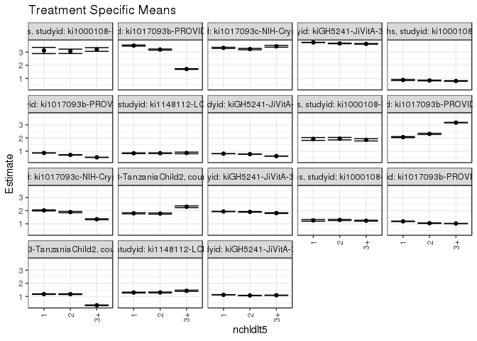

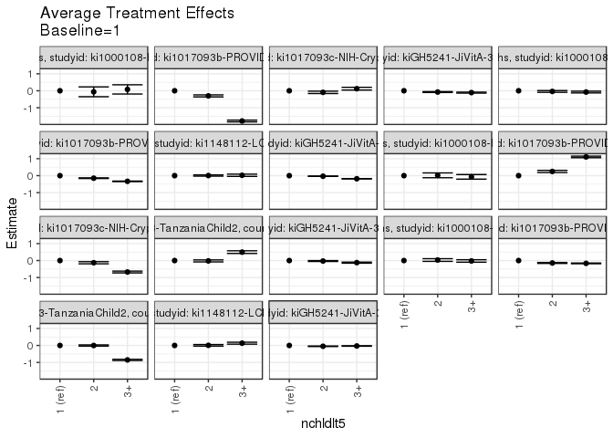

## Results Table

### Parameter: TSM

| agecat | studyid | country | intervention_level | baseline_level | estimate | ci_lower | ci_upper |
| --- | --- | --- | --- | --- | --- | --- | --- |
| 0-3 months | ki1000108-IRC | INDIA | 1 | NA | 3.1239029 | 2.8875622 | 3.3602435 |
| 0-3 months | ki1000108-IRC | INDIA | 2 | NA | 3.0618215 | 2.8936561 | 3.2299869 |
| 0-3 months | ki1000108-IRC | INDIA | 3+ | NA | 3.2038981 | 3.0656334 | 3.3421629 |
| 0-3 months | ki1017093b-PROVIDE | BANGLADESH | 1 | NA | 3.4981413 | 3.4555033 | 3.5407793 |
| 0-3 months | ki1017093b-PROVIDE | BANGLADESH | 2 | NA | 3.1963825 | 3.1536631 | 3.2391019 |
| 0-3 months | ki1017093b-PROVIDE | BANGLADESH | 3+ | NA | 1.7161309 | 1.6873482 | 1.7449135 |
| 0-3 months | ki1017093c-NIH-Crypto | BANGLADESH | 1 | NA | 3.3231910 | 3.2794165 | 3.3669656 |
| 0-3 months | ki1017093c-NIH-Crypto | BANGLADESH | 2 | NA | 3.2305376 | 3.1770920 | 3.2839832 |
| 0-3 months | ki1017093c-NIH-Crypto | BANGLADESH | 3+ | NA | 3.4443058 | 3.3764499 | 3.5121617 |
| 0-3 months | kiGH5241-JiVitA-3 | BANGLADESH | 1 | NA | 3.7378950 | 3.7251216 | 3.7506683 |
| 0-3 months | kiGH5241-JiVitA-3 | BANGLADESH | 2 | NA | 3.6624224 | 3.6393783 | 3.6854664 |
| 0-3 months | kiGH5241-JiVitA-3 | BANGLADESH | 3+ | NA | 3.6297410 | 3.6031732 | 3.6563088 |
| 3-6 months | ki1000108-IRC | INDIA | 1 | NA | 1.9250625 | 1.8159968 | 2.0341283 |
| 3-6 months | ki1000108-IRC | INDIA | 2 | NA | 1.9453536 | 1.8516580 | 2.0390492 |
| 3-6 months | ki1000108-IRC | INDIA | 3+ | NA | 1.8554652 | 1.7718234 | 1.9391070 |
| 3-6 months | ki1017093b-PROVIDE | BANGLADESH | 1 | NA | 2.0622633 | 2.0236383 | 2.1008883 |
| 3-6 months | ki1017093b-PROVIDE | BANGLADESH | 2 | NA | 2.3100409 | 2.2620137 | 2.3580681 |
| 3-6 months | ki1017093b-PROVIDE | BANGLADESH | 3+ | NA | 3.1669253 | 3.1486004 | 3.1852502 |
| 3-6 months | ki1017093c-NIH-Crypto | BANGLADESH | 1 | NA | 2.0183083 | 1.9792502 | 2.0573663 |
| 3-6 months | ki1017093c-NIH-Crypto | BANGLADESH | 2 | NA | 1.8895190 | 1.8366948 | 1.9423432 |
| 3-6 months | ki1017093c-NIH-Crypto | BANGLADESH | 3+ | NA | 1.3446744 | 1.3062933 | 1.3830554 |
| 3-6 months | ki1066203-TanzaniaChild2 | TANZANIA, UNITED REPUBLIC OF | 1 | NA | 1.7963956 | 1.7548132 | 1.8379780 |
| 3-6 months | ki1066203-TanzaniaChild2 | TANZANIA, UNITED REPUBLIC OF | 2 | NA | 1.7754920 | 1.7316453 | 1.8193386 |
| 3-6 months | ki1066203-TanzaniaChild2 | TANZANIA, UNITED REPUBLIC OF | 3+ | NA | 2.2934058 | 2.2246239 | 2.3621878 |
| 3-6 months | kiGH5241-JiVitA-3 | BANGLADESH | 1 | NA | 1.9341125 | 1.9207846 | 1.9474405 |
| 3-6 months | kiGH5241-JiVitA-3 | BANGLADESH | 2 | NA | 1.9064277 | 1.8818606 | 1.9309949 |
| 3-6 months | kiGH5241-JiVitA-3 | BANGLADESH | 3+ | NA | 1.8124397 | 1.7843624 | 1.8405169 |
| 6-12 months | ki1000108-IRC | INDIA | 1 | NA | 1.2585267 | 1.1943034 | 1.3227500 |
| 6-12 months | ki1000108-IRC | INDIA | 2 | NA | 1.2901506 | 1.2433984 | 1.3369027 |
| 6-12 months | ki1000108-IRC | INDIA | 3+ | NA | 1.2344696 | 1.1992897 | 1.2696494 |
| 6-12 months | ki1017093b-PROVIDE | BANGLADESH | 1 | NA | 1.1861657 | 1.1674212 | 1.2049103 |
| 6-12 months | ki1017093b-PROVIDE | BANGLADESH | 2 | NA | 1.0435618 | 1.0227176 | 1.0644061 |
| 6-12 months | ki1017093b-PROVIDE | BANGLADESH | 3+ | NA | 1.0208976 | 1.0136599 | 1.0281353 |
| 6-12 months | ki1066203-TanzaniaChild2 | TANZANIA, UNITED REPUBLIC OF | 1 | NA | 1.1780250 | 1.1547548 | 1.2012952 |
| 6-12 months | ki1066203-TanzaniaChild2 | TANZANIA, UNITED REPUBLIC OF | 2 | NA | 1.1751706 | 1.1487251 | 1.2016162 |
| 6-12 months | ki1066203-TanzaniaChild2 | TANZANIA, UNITED REPUBLIC OF | 3+ | NA | 0.3266239 | 0.2983168 | 0.3549311 |
| 6-12 months | ki1148112-LCNI-5 | MALAWI | 1 | NA | 1.2963882 | 1.2622587 | 1.3305177 |
| 6-12 months | ki1148112-LCNI-5 | MALAWI | 2 | NA | 1.3041091 | 1.2694211 | 1.3387972 |
| 6-12 months | ki1148112-LCNI-5 | MALAWI | 3+ | NA | 1.4304117 | 1.3819387 | 1.4788846 |
| 6-12 months | kiGH5241-JiVitA-3 | BANGLADESH | 1 | NA | 1.1228037 | 1.1145452 | 1.1310623 |
| 6-12 months | kiGH5241-JiVitA-3 | BANGLADESH | 2 | NA | 1.0741530 | 1.0605592 | 1.0877468 |
| 6-12 months | kiGH5241-JiVitA-3 | BANGLADESH | 3+ | NA | 1.0917296 | 1.0798102 | 1.1036490 |
| 12-24 months | ki1000108-IRC | INDIA | 1 | NA | 0.8826735 | 0.8379892 | 0.9273577 |
| 12-24 months | ki1000108-IRC | INDIA | 2 | NA | 0.8439275 | 0.8160382 | 0.8718168 |
| 12-24 months | ki1000108-IRC | INDIA | 3+ | NA | 0.8064859 | 0.7806653 | 0.8323066 |
| 12-24 months | ki1017093b-PROVIDE | BANGLADESH | 1 | NA | 0.8585634 | 0.8459152 | 0.8712116 |
| 12-24 months | ki1017093b-PROVIDE | BANGLADESH | 2 | NA | 0.7102232 | 0.6945649 | 0.7258814 |
| 12-24 months | ki1017093b-PROVIDE | BANGLADESH | 3+ | NA | 0.5247508 | 0.5163983 | 0.5331033 |
| 12-24 months | ki1148112-LCNI-5 | MALAWI | 1 | NA | 0.8364357 | 0.8119534 | 0.8609181 |
| 12-24 months | ki1148112-LCNI-5 | MALAWI | 2 | NA | 0.8424221 | 0.8171444 | 0.8676999 |
| 12-24 months | ki1148112-LCNI-5 | MALAWI | 3+ | NA | 0.8592054 | 0.7974058 | 0.9210049 |
| 12-24 months | kiGH5241-JiVitA-3 | BANGLADESH | 1 | NA | 0.8037776 | 0.7974758 | 0.8100793 |
| 12-24 months | kiGH5241-JiVitA-3 | BANGLADESH | 2 | NA | 0.7708213 | 0.7631870 | 0.7784555 |
| 12-24 months | kiGH5241-JiVitA-3 | BANGLADESH | 3+ | NA | 0.6216055 | 0.6143790 | 0.6288320 |

### Parameter: E(Y)

| agecat | studyid | country | intervention_level | baseline_level | estimate | ci_lower | ci_upper |
| --- | --- | --- | --- | --- | --- | --- | --- |
| 0-3 months | ki1000108-IRC | INDIA | NA | NA | 3.1729204 | 3.0609523 | 3.2848884 |
| 0-3 months | ki1017093b-PROVIDE | BANGLADESH | NA | NA | 3.4826706 | 3.4434873 | 3.5218539 |
| 0-3 months | ki1017093c-NIH-Crypto | BANGLADESH | NA | NA | 3.3028656 | 3.2646714 | 3.3410598 |
| 0-3 months | kiGH5241-JiVitA-3 | BANGLADESH | NA | NA | 3.7184715 | 3.7081256 | 3.7288173 |
| 3-6 months | ki1000108-IRC | INDIA | NA | NA | 1.8806738 | 1.8168757 | 1.9444719 |
| 3-6 months | ki1017093b-PROVIDE | BANGLADESH | NA | NA | 1.9654454 | 1.9303798 | 2.0005110 |
| 3-6 months | ki1017093c-NIH-Crypto | BANGLADESH | NA | NA | 2.0057973 | 1.9693775 | 2.0422170 |
| 3-6 months | ki1066203-TanzaniaChild2 | TANZANIA, UNITED REPUBLIC OF | NA | NA | 1.7933678 | 1.7575489 | 1.8291867 |
| 3-6 months | kiGH5241-JiVitA-3 | BANGLADESH | NA | NA | 1.9202273 | 1.9097659 | 1.9306887 |
| 6-12 months | ki1000108-IRC | INDIA | NA | NA | 1.2485668 | 1.2193308 | 1.2778028 |
| 6-12 months | ki1017093b-PROVIDE | BANGLADESH | NA | NA | 1.1731762 | 1.1558671 | 1.1904853 |
| 6-12 months | ki1066203-TanzaniaChild2 | TANZANIA, UNITED REPUBLIC OF | NA | NA | 1.1966694 | 1.1750524 | 1.2182863 |
| 6-12 months | ki1148112-LCNI-5 | MALAWI | NA | NA | 1.2808702 | 1.2546824 | 1.3070579 |
| 6-12 months | kiGH5241-JiVitA-3 | BANGLADESH | NA | NA | 1.1069910 | 1.1002444 | 1.1137377 |
| 12-24 months | ki1000108-IRC | INDIA | NA | NA | 0.8294859 | 0.8099817 | 0.8489901 |
| 12-24 months | ki1017093b-PROVIDE | BANGLADESH | NA | NA | 0.8575519 | 0.8455586 | 0.8695452 |
| 12-24 months | ki1148112-LCNI-5 | MALAWI | NA | NA | 0.8404906 | 0.8235383 | 0.8574429 |
| 12-24 months | kiGH5241-JiVitA-3 | BANGLADESH | NA | NA | 0.7967582 | 0.7914423 | 0.8020741 |

### Parameter: ATE

| agecat | studyid | country | intervention_level | baseline_level | estimate | ci_lower | ci_upper |
| --- | --- | --- | --- | --- | --- | --- | --- |
| 0-3 months | ki1000108-IRC | INDIA | 1 | 1 | 0.0000000 | 0.0000000 | 0.0000000 |
| 0-3 months | ki1000108-IRC | INDIA | 2 | 1 | -0.0620814 | -0.3515204 | 0.2273576 |
| 0-3 months | ki1000108-IRC | INDIA | 3+ | 1 | 0.0799952 | -0.1926227 | 0.3526132 |
| 0-3 months | ki1017093b-PROVIDE | BANGLADESH | 1 | 1 | 0.0000000 | 0.0000000 | 0.0000000 |
| 0-3 months | ki1017093b-PROVIDE | BANGLADESH | 2 | 1 | -0.3017588 | -0.3622739 | -0.2412436 |
| 0-3 months | ki1017093b-PROVIDE | BANGLADESH | 3+ | 1 | -1.7820104 | -1.8341048 | -1.7299160 |
| 0-3 months | ki1017093c-NIH-Crypto | BANGLADESH | 1 | 1 | 0.0000000 | 0.0000000 | 0.0000000 |
| 0-3 months | ki1017093c-NIH-Crypto | BANGLADESH | 2 | 1 | -0.0926534 | -0.1614141 | -0.0238928 |
| 0-3 months | ki1017093c-NIH-Crypto | BANGLADESH | 3+ | 1 | 0.1211148 | 0.0405139 | 0.2017156 |
| 0-3 months | kiGH5241-JiVitA-3 | BANGLADESH | 1 | 1 | 0.0000000 | 0.0000000 | 0.0000000 |
| 0-3 months | kiGH5241-JiVitA-3 | BANGLADESH | 2 | 1 | -0.0754726 | -0.1009828 | -0.0499624 |
| 0-3 months | kiGH5241-JiVitA-3 | BANGLADESH | 3+ | 1 | -0.1081539 | -0.1364971 | -0.0798108 |
| 3-6 months | ki1000108-IRC | INDIA | 1 | 1 | 0.0000000 | 0.0000000 | 0.0000000 |
| 3-6 months | ki1000108-IRC | INDIA | 2 | 1 | 0.0202911 | -0.1222164 | 0.1627985 |
| 3-6 months | ki1000108-IRC | INDIA | 3+ | 1 | -0.0695974 | -0.2059254 | 0.0667307 |
| 3-6 months | ki1017093b-PROVIDE | BANGLADESH | 1 | 1 | 0.0000000 | 0.0000000 | 0.0000000 |
| 3-6 months | ki1017093b-PROVIDE | BANGLADESH | 2 | 1 | 0.2477776 | 0.1825132 | 0.3130419 |
| 3-6 months | ki1017093b-PROVIDE | BANGLADESH | 3+ | 1 | 1.1046620 | 1.0593989 | 1.1499251 |
| 3-6 months | ki1017093c-NIH-Crypto | BANGLADESH | 1 | 1 | 0.0000000 | 0.0000000 | 0.0000000 |
| 3-6 months | ki1017093c-NIH-Crypto | BANGLADESH | 2 | 1 | -0.1287893 | -0.1914230 | -0.0661556 |
| 3-6 months | ki1017093c-NIH-Crypto | BANGLADESH | 3+ | 1 | -0.6736339 | -0.7267201 | -0.6205477 |
| 3-6 months | ki1066203-TanzaniaChild2 | TANZANIA, UNITED REPUBLIC OF | 1 | 1 | 0.0000000 | 0.0000000 | 0.0000000 |
| 3-6 months | ki1066203-TanzaniaChild2 | TANZANIA, UNITED REPUBLIC OF | 2 | 1 | -0.0209036 | -0.0798532 | 0.0380460 |
| 3-6 months | ki1066203-TanzaniaChild2 | TANZANIA, UNITED REPUBLIC OF | 3+ | 1 | 0.4970102 | 0.4175859 | 0.5764346 |
| 3-6 months | kiGH5241-JiVitA-3 | BANGLADESH | 1 | 1 | 0.0000000 | 0.0000000 | 0.0000000 |
| 3-6 months | kiGH5241-JiVitA-3 | BANGLADESH | 2 | 1 | -0.0276848 | -0.0549512 | -0.0004184 |
| 3-6 months | kiGH5241-JiVitA-3 | BANGLADESH | 3+ | 1 | -0.1216728 | -0.1536826 | -0.0896631 |
| 6-12 months | ki1000108-IRC | INDIA | 1 | 1 | 0.0000000 | 0.0000000 | 0.0000000 |
| 6-12 months | ki1000108-IRC | INDIA | 2 | 1 | 0.0316239 | -0.0471886 | 0.1104364 |
| 6-12 months | ki1000108-IRC | INDIA | 3+ | 1 | -0.0240571 | -0.0961206 | 0.0480063 |
| 6-12 months | ki1017093b-PROVIDE | BANGLADESH | 1 | 1 | 0.0000000 | 0.0000000 | 0.0000000 |
| 6-12 months | ki1017093b-PROVIDE | BANGLADESH | 2 | 1 | -0.1426039 | -0.1706642 | -0.1145437 |
| 6-12 months | ki1017093b-PROVIDE | BANGLADESH | 3+ | 1 | -0.1652682 | -0.1854545 | -0.1450818 |
| 6-12 months | ki1066203-TanzaniaChild2 | TANZANIA, UNITED REPUBLIC OF | 1 | 1 | 0.0000000 | 0.0000000 | 0.0000000 |
| 6-12 months | ki1066203-TanzaniaChild2 | TANZANIA, UNITED REPUBLIC OF | 2 | 1 | -0.0028544 | -0.0367218 | 0.0310131 |
| 6-12 months | ki1066203-TanzaniaChild2 | TANZANIA, UNITED REPUBLIC OF | 3+ | 1 | -0.8514011 | -0.8873472 | -0.8154550 |
| 6-12 months | ki1148112-LCNI-5 | MALAWI | 1 | 1 | 0.0000000 | 0.0000000 | 0.0000000 |
| 6-12 months | ki1148112-LCNI-5 | MALAWI | 2 | 1 | 0.0077210 | -0.0372247 | 0.0526666 |
| 6-12 months | ki1148112-LCNI-5 | MALAWI | 3+ | 1 | 0.1340235 | 0.0771228 | 0.1909241 |
| 6-12 months | kiGH5241-JiVitA-3 | BANGLADESH | 1 | 1 | 0.0000000 | 0.0000000 | 0.0000000 |
| 6-12 months | kiGH5241-JiVitA-3 | BANGLADESH | 2 | 1 | -0.0486507 | -0.0637963 | -0.0335051 |
| 6-12 months | kiGH5241-JiVitA-3 | BANGLADESH | 3+ | 1 | -0.0310742 | -0.0456338 | -0.0165145 |
| 12-24 months | ki1000108-IRC | INDIA | 1 | 1 | 0.0000000 | 0.0000000 | 0.0000000 |
| 12-24 months | ki1000108-IRC | INDIA | 2 | 1 | -0.0387460 | -0.0913653 | 0.0138733 |
| 12-24 months | ki1000108-IRC | INDIA | 3+ | 1 | -0.0761875 | -0.1278147 | -0.0245603 |
| 12-24 months | ki1017093b-PROVIDE | BANGLADESH | 1 | 1 | 0.0000000 | 0.0000000 | 0.0000000 |
| 12-24 months | ki1017093b-PROVIDE | BANGLADESH | 2 | 1 | -0.1483402 | -0.1691765 | -0.1275040 |
| 12-24 months | ki1017093b-PROVIDE | BANGLADESH | 3+ | 1 | -0.3338126 | -0.3496540 | -0.3179711 |
| 12-24 months | ki1148112-LCNI-5 | MALAWI | 1 | 1 | 0.0000000 | 0.0000000 | 0.0000000 |
| 12-24 months | ki1148112-LCNI-5 | MALAWI | 2 | 1 | 0.0059864 | -0.0292038 | 0.0411766 |
| 12-24 months | ki1148112-LCNI-5 | MALAWI | 3+ | 1 | 0.0227696 | -0.0437027 | 0.0892420 |
| 12-24 months | kiGH5241-JiVitA-3 | BANGLADESH | 1 | 1 | 0.0000000 | 0.0000000 | 0.0000000 |
| 12-24 months | kiGH5241-JiVitA-3 | BANGLADESH | 2 | 1 | -0.0329563 | -0.0426475 | -0.0232651 |
| 12-24 months | kiGH5241-JiVitA-3 | BANGLADESH | 3+ | 1 | -0.1821720 | -0.1918900 | -0.1724541 |